# R Markdown alapok

Tajti András - Tóth Tímea

2018.02.04.

# 1 . Röviden a Markdownról

Ha szövegszerkesztésre gondolunk, akkor az egyik végletet az olyan WYSIWYG (“**w**hat **y**ou **s**ee **i**s **w**hat **y**ou **g**et”) szövegszerkesztők jelentik, mint a Microsoft Word. A szerkesztő felületre bevitt szöveg ugyanúgy néz ki kész formájában, mentés után, vagy nyomtatásban, mint miközben szerkesztjük. A másik végponton olyan eszközök, nyelvek helyezkednek el, mint például a HTML, ahol a szerkesztőbe gépelt szöveg jelentősen eltér a végeredményként kapott outputtól, a formázást valamilyen syntaxszal határozzuk meg.

Összehasonlításképpen egymás mellé tehetjük egy Word típusú szerkesztőfelület képét, és az azonos outputot eredményező HTML kódot.

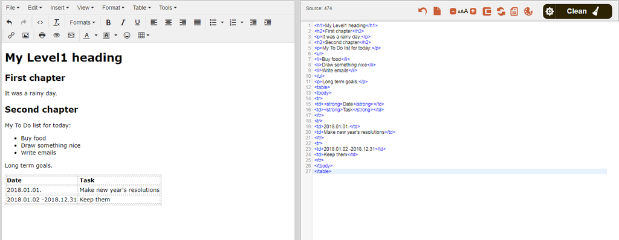

*Word - HTML összehasonlítás*

A screenshot egy online [HTML szerkesztő oldalról](https://html-online.com/editor/) származik. A bal oldalon egy Word típusú szerkesztő felület található, a jobb oldalon pedig egy HTML szerkesztő felület kap helyet. Bármelyik oldal szerkeszthető, ha az egyik oldal változik, akkor a változtatásnak megfelelően módosul a másik oldal is. Így interaktívan kipróbálható, hogy az egyes formázásoknak mi a HTML megfelelője, vagy hogy egy HTML kód milyen outputot eredményez. A WYSIWYG megközelítési mód előnye, hogy egyszerű, és könnyen elsajátítható, a syntax alkalmazása viszont megkönnyíti a stílus konzisztenciájának fenntartását, a stílus változása esetén egyszerűbb a módosítás, és az ilyen módon létrehozott dokumentumok könnyebben értelmezhetőek más programok számára.

A Markdown nyelv a két végpont között helyezkedik el, minimális syntax alkalmazásával hozunk vele létre formázott szöveget. Az előző példa Markdown syntaxa:

```
# My Level1 heading

## First chapter

It was a rainy day.

## Second chapter

My To Do list for today:

* Buy food
* Draw something nice
* Write emails

Long term goals:

Date | Task
--- | ---
2018.01.01 | Make New Year's resolutions
2018.01.02 - 2018.12.31 | Keep them
```

Az R Markdown a Markdown nyelvre épül, a célja, hogy egyszerűen és gyorsan létre lehessen hozni olyan dokumentumokat, amik nem csak az eredményeket, hanem az azt létrehozó kódot is tartalmazzák. A kutatások eredményei így könnyebben megoszthatóvá, és reprodukálhatóvá válnak. Az R Markdown dokumentumok megírásuk után konvertálhatóak más formátumú fájlokká. A kuzuson mi .html outputtá fogjuk alakítani a megosztáshoz a dokumentumainkat.

# 2 . R Markdown syntax

A 6 címsor stílust különböztetünk meg, amiket a címsor szintjének megfelelő számú `#` jelöl.

```
# Címsor 1
## Címsor 2
### Címsor 3
#### Címsor 4
##### Címsor 5
###### Címsor 6
```

**Italic formázás:** egy * vagy egy _, például `*szöveg*` -> *szöveg*

**Bold formázás:** két * vagy két _, például `**szöveg**` -> **szöveg**

**Felső index:** ^, például `2^3^ = 8` -> 2<sup>3</sup> = 8

**Alsó index:** ~, például `Lábjegyzet~1~` -> Lábjegyzet<sub>1</sub>

Ha listát szeretnénk létrehozni, akkor a lista alatt és felett ki kell hagyni egy sort. A rendezetlen lista elemeit *, a rendezett lista elemeit a listaelem sorszáma előzi meg. Ha a lista többszintű, akkor az alsóbb szintek mindig két szóközzel, vagy két tabbal beljebb kezdődnek.

```
**Rendezetlen lista**

* lista elem
* még egy lista elem
    * ezen belül még egy
    * és még egy
* ez alatt rendezett elemek vannak
    1. első
    2. második
    3. harmadik
```

**Rendezetlen lista**

- lista elem
- még egy lista elem
  - ezen belül még egy
  - és még egy
- ez alatt rendezett elemek vannak
  1. első
  2. második
  3. harmadik

```
**Rendezett lista**

1. elem1
2. elem2
    1. elem
    2. elem2
    3. elem3
3. elem3
    * nem rendezett
    * ez sem rendezett
```

**Rendezett lista**

1. elem1
2. elem2
   1. elem
   2. elem2
   3. elem3
3. elem3
   - nem rendezett
   - ez sem rendezett

**Link:** `[Link szövege](hiperlink)`, például `[RStudio honlap](www.rstudio.com)` -> RStudio honlap

**Kép beszúrása:** `![Kép aláírás](elérési/útvonal/kép.png)`, például `![Chart építők](img/building-statistics.jpg)` ->

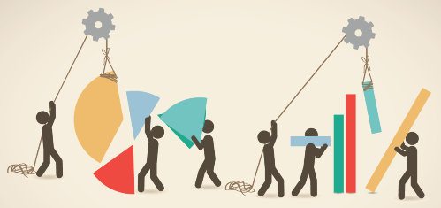

*Chart építők*

További formázási lehetőségek a [Reference Guide](https://www.rstudio.com/wp-content/uploads/2015/03/rmarkdown-reference.pdf)-ban találhatóak, vagy az R Markdownnal kapcsolatos legfontosabb ismereteket összefoglaló [cheatsheet](https://www.rstudio.com/wp-content/uploads/2016/03/rmarkdown-cheatsheet-2.0.pdf)-en.

Ha a Markdown adta lehetőségek nem elégítik ki az igényeinket, vagy a formázás már túlságosan nehézkessé válik ilyen módon, akkor két lehetőség áll előttünk. Egyrészt beszúrhatunk R (vagy más nyelven írt) kódrészleteket, úgynevezett ‘code chunk’-okat, amik elvégzik a feladatot, másrészt a folyó szövegben a Markdown jelölések helyett használhatunk HTML és CSS syntaxot is. A kurzus során az első megoldásra támaszkodunk majd, de érdemes példát látnunk a másodikra is.

A HTML gazdagabb kifejezőkészségű nyelv, mint a Markdown, és így összetettebb a syntaxa is. Míg a Markdown esetében egy-két speciális karakterrel juttatjuk érvényre a legtöbb formázást, addig a HTML nyelvben a legtöbb esetben tag párokat alkalmazunk. A Címsor1 jelölése például Markdownt használva `#Címsor1`, HTML-ben ugyanez `<h1>Címsor1</h1>`. A HTML tag párok és a Markdown jelölések jellemzően csak kijelölik egy-egy szövegrészlet szerepét pl. címsor vagy link, az egyes szerepekhez tartoznak default formázások, a Címsor1 például nagyobb mint a Címsor2 vagy Címsor3. A Markdown esetében közvetlenül a szövegben (inline) nem módosíthatjuk ezeket a stílusokat, csak külső CSS stílus fájlok megadásával, ahogy ezt később látni fogjuk. HTML tagek használata esetén mindkét lehetőség adott.

Ha különböző színű címsorokat szeretnénk beszúrni, akkor azt például így tehetjük meg:

```
<h1 style="color:#8b0000">Címsor1</h1>
<h2 style="color:#ca0002">Címsor2</h2>
<h3 style="color:#ff3200">Címsor3</h3>
<h4 style="color:#ff8c00">Címsor4</h4>
<h5 style="color:#ffc900">Címsor5</h5>
<h6 style="color:#ffff00">Címsor6</h6>
```

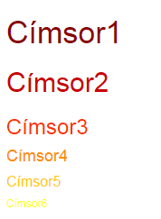

A tag típusa adja meg, hogy milyen típusú elemről beszélünk (Címsor1 - Címsor6), a `style` paramétert követő CSS kód részlet pedig stílusát, ebben az esetben a címsorok színét.

Ha a korábban beillesztett képet szeretnénk középre rendezni, és kerettel ellátni, akkor azt a következő HTML kóddal érhetjük el:

```
<figure>
<center>
<img style="border:5px solid darkred;" src="img/building-statistics.jpg" alt="Chart építők" >
<figcaption>Chart építők</figcaption>
</center>
</figure>
```

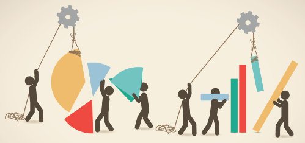

Chart építők

A `<center>` tag középre rendezi az általa közrezárt elemeket, az `<img>` tag beszúrja a képet a `style` paraméterben meghatározott stílussal, a `<figcaption>` tag pedig képaláírást ad a szöveghez.

Ha közvetlenül a folyószövegbe írunk HTML és CSS kódrészleteket, akkor ügyelnünk kell arra, hogy ne formázzuk ezeket a beágyazottsági szinteknek megfelelően szóközökkel vagy tabokkal, mivel ezeknek a Markdown nyelvben is jelentése van, és a program nem tudja majd megfelelően értelmezni a kódrészletet. A két nyelv másféle módon is összeakadhat, ezért általánosságban érdemesebb inkább csak kisebb, egyszerűbb feladatokra használni HTML-t az R Markdown dokumentumokban.

Az eddigiek során az R Markdown dokumentumok Markdown részéről beszéltünk, és a folyószöveg kialakításáról. Most következik az R rész tárgyalása, vagyis hogy hogyan ágyazhatóak be a kód részletek a dokumentumokba.

Az erre kialakított megoldás az úgynevezett code chunkok alkalmazása. Az egyes R chunkokban a kódot normál R syntaxnak megfelelően kell megírni, a chunkok egy folytatólagos scriptet alkotnak, amelyeket a köztük elhelyezkedő folyószöveg nem befolyásol. Ennek eredményeként, ha egy kód részletben létrehozunk egy változót, vagy betöltünk egy csomagot, akkor a változó a későbbi kód részletekben is elérhető lesz, a csomagot pedig nem kell újra betölteni. Az egyes chunkok viselkedése, például, hogy a program HTML-lé konvertáláskor lefuttassa-e a benne található kódot, és ha lefuttatja, akkor a kódot és a létrejövő outputot megjelenítse-e a létrejövő HTML dokumentumban, az adott chunk fejlécében állítható.

A chunkok beállításainak bemutatásához először hozzunk létre egy új R Markdown dokumentumot.

# 3 . R Markdown fájl létrehozása

Új R Markdown dokumentum megnyitásához az *Új fájl* menüpont alatt kell kiválasztanunk az *R Markdown…* lehetőséget.

[figure not shown]

*Új Markdown dokumentum*

A felugró ablakban meg tudjuk adni a dokumentum címét, a szerzők nevét, és hogy milyen outputot szeretnénk majd kapni. A kurzus során HTML formátumú dokumentumokat fogunk készíteni.

[figure not shown]

*Új Markdown dokumentum típusa*

A létrejövő új dokumentum már tartalmaz szöveget és kódot, ami az R Markdown lehetőségeit hivatott bemutatni.

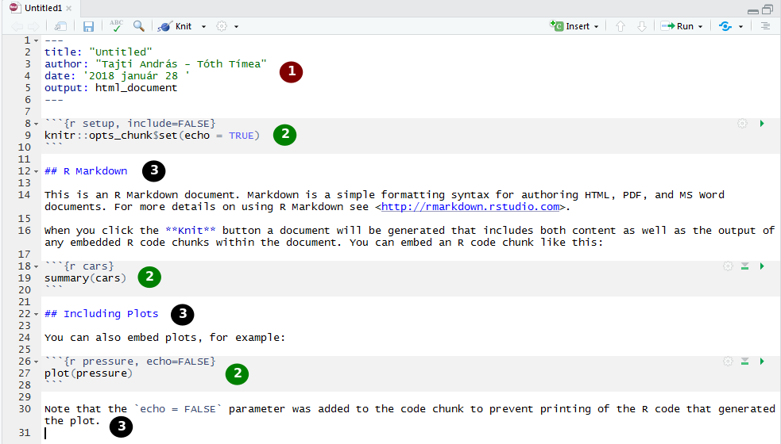

*Az újonnan létrejövő dokumentum*

A script elején található a YAML fejléc (1), ami a dokumentumra vonatkozó metaadatokat tartalmazza, úgy mint cím, szerző neve, dátum, és az outputként végül létrejövő dokumentum típusa. A beállítások mindegyike módosítható. Ha a dátumot például szeretnénk mindig egyenlővé tenni a futtatás napjával, akkor a date paraméternél a következő értéket kell megadni R kódrészletként: `format(Sys.Date(), "%Y.%m.%d.")`

A fájl ezt követően felváltva tartalmaz kód részleteket (2) és folyószöveget (3). A kód részletek két ``` között jelennek meg. Új kód részletet a `Ctr+I` billentyű kombinációval lehet beszúrni vagy az insert ikonnal. A kód részleteken belül a fenti kapcsos zárójel tartalmazza a fejlécet. Az első paraméter a code chunk nyelve, ez a fenti példában minden esetben R.

Ezt opcionálisan megadható paraméterek követik, elsőként a code chunk neve. A kód részleteket több okból is érdemes elneveznünk. Egyrészt ezek segítségével könnyebben navigálhatunk a fájlban, a Markdown panel alján található felnyíló menüt használva tetszőleges kód részlethez vagy címhez ugorhatunk. Másrészt az elnevezések szükségesek a cache beállításokhoz, ha valamelyik kód részlet lassan fut, akkor eltároltathatjuk az eredményét, és hogy milyen körülmények között kell mégis újrafuttatni.

A további opcionális paraméterek elsősorban a kód lefutását és az output megjelenítését hivatottak befolyásolni, a hatókörük az adott code chunk. Ha több paramétert is magadunk, akkor ezek vesszővel elválasztva szerepelnek majd.

A leggyakrabban használt paraméter beállítások:

- `eval=FALSE`: Nem értékelődik ki, és fut le a kód a kód részletben, és így output sem keletkezik a code chunkból. Példa kódok megmutatására érdemes használni, vagy ha időszakosan ki akarunk iktatni egy kód részletet.
- `include = FALSE`: A kód lefut, de sem az eredménye sem maga a kód nem kerül bele az outputba. A kezdeti setup-ot tartalmazó kód részletnél érdemes alkalmazni, aminek a tartalma nem releváns a végső output szempontjából, ahogy azt a fenti példán is láthatjuk.
- `echo = FALSE`: A kód lefut, az eredménye bekerül az outputba, de maga a kód nem. Olyan esetekben érdemes használni a beállítást, amikor a célközönség tagjai nem R felhasználók, és csak a futtatás eredménye érdekes számukra. A fenti példában a plotot létrehozó chunk beállításai tartalmaznak ilyet.
- `message = FALSE`: A kód lefut, az eredmény és a kód is bekerül az outputba, de a futás közben keletkező, például a csomagbetöltéshez kapcsolódó üzenetek nem.
- `warning = FALSE`: A kód lefut, az eredmény és a kód is bekerül az outputba, de a futás közben keletkező figyelmeztető üzenetek nem, például, ha a ggplot2 ábráról a tengelybeállítások miatt lemaradnak adatpontok.
- `results = 'hide'`: A szöveges eredmény nem kerül bele az outputba.
- `fig.show = 'hide'`: A keletkező plotok nem kerülnek be az outputba.
- `error = TRUE`: A futás nem áll le, ha valahol hiba keletkezik, hibakeresés során lehet hasznos, vagy hibaüzenetek bemutatására.

A beágyazott képekre és plotokra vonatkozó beállítások:

- `fig.height`, `fig.width`: képek és ábrák hosszúsága és szélessége.

A code chunkokra vonatkozó beállítások a kód részletek jobb felső sarkában található fogaskerék menüpontjain keresztül is módosíthatóak.

A paraméterek teljes listája [itt](https://yihui.name/knitr/options/) érhető el.

Ha az előbb megnyitott példa R Markdown dokumentumból szeretnénk .html fájlt előállítani, amit majd másokkal is megoszthatunk, akkor azt legegyszerűbben a ikonra kattintva tehetjük meg. A program először kéri a Markdown dokumentum elmentését, a fájlnak .Rmd kiterjesztést kell adnunk, máskülönben a konvertálást végző `knitr` csomag nem tudja helyesen értelmezni a dokumentumot. Ha a felugró ablakban a csomag a karakterkódolásról kérdez, akkor választhatjuk a CP1250-t, ami a default beállítás. A Windows ezt a karakterkódolást használja azokhoz a közép- és kelet-európai nyelvekhez, amik latin ábécén alapulnak.

A Console panel R Markdown fülén követhetjük, ahogy a `knitr` feldolgozza a dokumentumot. Ha lefutott a kód, akkor az új HTML oldal egy felugró ablakban jelenik meg. Az elnevezése az alapjául szolgáló .Rmd fájléval azonos. A **teszt.Rmd** fájl eredménye például **teszt.html**. Az oldal a böngészőben is megtekinthető, ha a felugró ablakban az lehetőségre kattintunk. A `knitr` alapbeállításként az oldalba kódolja az összes szükséges forrást, például képeket, style sheetet, amit a dokumentumba illesztettünk, így a létrejövő HTML fájl a mappa más elemeitől függetlenül mozgatható, továbbítható másoknak. Ha például a **teszt.html** fájlt átmásoljuk egy másik mappába, és duplán rákattintunk, akkor az oldal onnan is teljes tartalmával nyílik meg a böngészőben. Összehasonlításképpen, ha letöltitek például a [Felvi](https://www.felvi.hu/) oldalát, és mentésnél a HTML only lehetőséget választjátok, majd megpróbáljátok megnyitni a lementett oldalt a böngészőben, akkor a korábban a weblapon látott képek hiányozni fognak az oldalról, és az oldal formázása is teljesen más lesz. Ha ezek után lementitek az oldalt teljes tartalommal, és úgy nyitjátok meg, akkor az online verzióval közel azonos kép fogad. A honlapok többsége úgy van felépítve, hogy a képeket, és a formázáshoz használt kódot különálló fájlból tölti be.

Az R Markdown dokumentum nemcsak egyben futtatható le, az R Studioban az .Rmd fájlok notebookként is működnek, vagyis az egyes kódrészletek külön-külön interaktívan a .Rmd fájlon belül is lefuttathatóak. Ezt kipróbálhatjuk úgy, hogy megnyomjuk a teszt.Rmd fájl code chunkjainak jobb felső sarkán található futtatás ikont. Az első, `include=FALSE` beállítással rendelkező chunk futtatást követően nem ad eredményt, a második outputja egy összefoglaló táblázat a speed és a dist változóról, a harmadiké pedig egy plot. Ha egy chunkon belül több eredmény is létrejön, akkor azok között ablakszerűen lehet váltogatni. Például a `plot(pressure)` sort a második chunkba másolva a chunk újrafuttatása után a következő eredményt kapjuk:

[figure not shown]

*R Markdown dokumentum mint notebook*

# 4 . Kiegészítő témakörök

Az eddig elsajátított ismeretek már elegendőek ahhoz, hogy működőképes R Markdown dokumentumokat hozzunk létre, a továbbiakban kitérünk pár olyan eszközre, amivel esztétikusabbá, könnyebben használhatóvá tehetőek.

## 4.1 Táblázatok

Ha nem módosítjuk az eredményt, akkor az R a táblázatokat szöveges outputként jeleníti meg, függvények alkalmazásával azonban szebb eredményt érhetünk el. A `knitr` beépített függvénye erre a célra a `kable`.

```r
library(knitr)
library(gapminder)

# A kable függvény a futás környezetétől függően dönti el,
# hogy milyen formátumú legyen majd az output pl. html vagy latex
kable(head(gapminder),caption = "A Gapminder adattábla első sorai")
```

A Gapminder adattábla első sorai

| country | continent | year | lifeExp | pop | gdpPercap |
| --- | --- | --- | --- | --- | --- |
| Afghanistan | Asia | 1952 | 28.801 | 8425333 | 779.4453 |
| Afghanistan | Asia | 1957 | 30.332 | 9240934 | 820.8530 |
| Afghanistan | Asia | 1962 | 31.997 | 10267083 | 853.1007 |
| Afghanistan | Asia | 1967 | 34.020 | 11537966 | 836.1971 |
| Afghanistan | Asia | 1972 | 36.088 | 13079460 | 739.9811 |
| Afghanistan | Asia | 1977 | 38.438 | 14880372 | 786.1134 |

A táblázaton belül formázhatóak az egyes oszlopok, például megadhatjuk, hogy hány tizedesjegyig legyenek megjelenítve az értékek, merre rendezzük az oszlopokat, új oszlop neveket adhatunk meg. Az oszlopneveken belül html kódot is használhatunk, ha az `escape` paramétert `FALSE`-ra állítjuk. A `<br/>` (break) tag-gel például több sorra tördelhetjük az oszlopnevet.

```r
kable(head(gapminder)
      ,caption = "A Gapminder adattábla első sorai"
      ,col.names = c("Ország","Kontinens","Év","Várható<br/>élettartam","Népesség","GDP/fő") # oszlopnevek
      ,digits = 2 # hány tizedesjegyet jelenítünk meg
      ,align = c(rep("l", 2), rep("c", 2), rep("r", 2)) # oszlopok rendezése
      ,format.args = list(decimal.mark = ",", big.mark = " ") # tizedesjel és ezres elválasztó
      ,escape = FALSE) # értelmezze htmlként a html tageket, ne pedig szövegként
```

A Gapminder adattábla első sorai

| Ország | Kontinens | Év | Várható élettartam | Népesség | GDP/fő |
| --- | --- | --- | --- | --- | --- |
| Afghanistan | Asia | 1 952 | 28,80 | 8 425 333 | 779,45 |
| Afghanistan | Asia | 1 957 | 30,33 | 9 240 934 | 820,85 |
| Afghanistan | Asia | 1 962 | 32,00 | 10 267 083 | 853,10 |
| Afghanistan | Asia | 1 967 | 34,02 | 11 537 966 | 836,20 |
| Afghanistan | Asia | 1 972 | 36,09 | 13 079 460 | 739,98 |
| Afghanistan | Asia | 1 977 | 38,44 | 14 880 372 | 786,11 |

A `kableExtra` csomaggal további beállítások vállnak elérhetővé. Például elérhetjük, hogy a táblázat ne töltse ki teljes szélességében az oldalt, rendezhetjük a táblázatot az oldalon belül, vagy az oszlopok értékétől függő formázást tehetünk rá. A `kable` függvény alapesetben markdown táblázattá alakítja a táblázatot, a `knitr` pedig a kívánt output típusától függően alakítja tovább HTML-lé vagy más formátummá. Ez a megoldás lehetővé teszi, hogy ne kelljen változtatni a kódon, ha például HTML helyett PDF outputot szeretnénk, viszont mivel a markdown ezt nem teszi lehetővé, nem tudunk összetett formázásokat végrehajtani a táblázaton. A következő példában ezért rögzítjük, hogy a `kabble` függvény HTML formátumú táblázatot adjon vissza.

```r
library(kableExtra)

# kable html táblázat formázás nélkül
kable(head(gapminder), "html")
```

| country | continent | year | lifeExp | pop | gdpPercap |
| --- | --- | --- | --- | --- | --- |
| Afghanistan | Asia | 1952 | 28.801 | 8425333 | 779.4453 |
| Afghanistan | Asia | 1957 | 30.332 | 9240934 | 820.8530 |
| Afghanistan | Asia | 1962 | 31.997 | 10267083 | 853.1007 |
| Afghanistan | Asia | 1967 | 34.020 | 11537966 | 836.1971 |
| Afghanistan | Asia | 1972 | 36.088 | 13079460 | 739.9811 |
| Afghanistan | Asia | 1977 | 38.438 | 14880372 | 786.1134 |

```r
# kable html táblázat default twitter bootstrap témával
kable(head(gapminder), "html") %>% # pipe syntax-szal adható tovább az első lépés eredménye
  kable_styling()
```

| country | continent | year | lifeExp | pop | gdpPercap |
| --- | --- | --- | --- | --- | --- |
| Afghanistan | Asia | 1952 | 28.801 | 8425333 | 779.4453 |
| Afghanistan | Asia | 1957 | 30.332 | 9240934 | 820.8530 |
| Afghanistan | Asia | 1962 | 31.997 | 10267083 | 853.1007 |
| Afghanistan | Asia | 1967 | 34.020 | 11537966 | 836.1971 |
| Afghanistan | Asia | 1972 | 36.088 | 13079460 | 739.9811 |
| Afghanistan | Asia | 1977 | 38.438 | 14880372 | 786.1134 |

```r
# Váltakozó színű sorok (striped),
# amik reagálnak az egér mozgásra (hover)

kable(head(gapminder), "html") %>%
  kable_styling(bootstrap_options = c("striped", "hover"))
```

| country | continent | year | lifeExp | pop | gdpPercap |
| --- | --- | --- | --- | --- | --- |
| Afghanistan | Asia | 1952 | 28.801 | 8425333 | 779.4453 |
| Afghanistan | Asia | 1957 | 30.332 | 9240934 | 820.8530 |
| Afghanistan | Asia | 1962 | 31.997 | 10267083 | 853.1007 |
| Afghanistan | Asia | 1967 | 34.020 | 11537966 | 836.1971 |
| Afghanistan | Asia | 1972 | 36.088 | 13079460 | 739.9811 |
| Afghanistan | Asia | 1977 | 38.438 | 14880372 | 786.1134 |

```r
# Nem tölti ki az egész sort (full_width = FALSE)
# Balra van rendezve (position = "left")
# A kabble függvényen belül továbbra is alkalmazhatóak az előbb látott beállítások

kable(head(gapminder), "html"
      ,col.names = c("Ország","Kontinens","Év","Várható<br/>élettartam","Népesség","GDP/fő") # oszlopnevek
      ,digits = 2 # hány tizedesjegyet jelenítünk meg
      ,align = c(rep("l", 2), rep("c", 2), rep("r", 2)) # oszlopok rendezése
      ,format.args = list(decimal.mark = ",", big.mark = " ") # tizedesjel és ezres elválasztó
      ,escape = F) %>% # HTML-ként értelmezendőek a HTML tagek
  kable_styling(bootstrap_options = c("striped","hover"), full_width = F, position = "left")
```

| Ország | Kontinens | Év | Várható élettartam | Népesség | GDP/fő |
| --- | --- | --- | --- | --- | --- |
| Afghanistan | Asia | 1 952 | 28,80 | 8 425 333 | 779,45 |
| Afghanistan | Asia | 1 957 | 30,33 | 9 240 934 | 820,85 |
| Afghanistan | Asia | 1 962 | 32,00 | 10 267 083 | 853,10 |
| Afghanistan | Asia | 1 967 | 34,02 | 11 537 966 | 836,20 |
| Afghanistan | Asia | 1 972 | 36,09 | 13 079 460 | 739,98 |
| Afghanistan | Asia | 1 977 | 38,44 | 14 880 372 | 786,11 |

```r
library(dplyr)

# Feltételes formázás cell_spec függvénnyel és dplyrrel
gapminder %>%
  filter(year == 2007) %>%
  select(country,continent,pop) %>%
  head() %>%
  mutate(
    # A country oszlop betűtípusa bold, a színe a pop értékétől függ
    country = cell_spec(country, color = ifelse(pop > 40000000, "grey", "black"),
                        bold = T),
    # 40M feletti értékek jelölése zöld színű bold betűtípus,
    # az ezres elválasztó jel a szóköz
    pop = cell_spec(format(pop, big.mark = " "),"html",
                    color = ifelse(pop > 40000000, "grey", "black"),
                    bold = ifelse(pop > 40000000, T, F)),
    # A continent oszlopban a szöveg háttere kontinensenként eltérő
    continent = cell_spec(continent,"html",color = "white", bold = T,
                          background = factor(continent,
                                              c("Africa", "Americas", "Asia", "Europe", "Oceania"),
                                              c("#e41a1c", "#377eb8", "#4daf4a","#984ea3","#ff7f00"))))%>%
  kable("html"
      ,col.names = c("Ország","Kontinens","Népesség")
      ,digits = 2
      ,align = c(rep("l", 2), rep("r", 1))
      ,escape = F) %>%
  kable_styling(bootstrap_options = c("striped","hover"), full_width = F, position = "left")
```

| Ország | Kontinens | Népesség |
| --- | --- | --- |
| Afghanistan | Asia | 31 889 923 |
| Albania | Europe | 3 600 523 |
| Algeria | Africa | 33 333 216 |
| Angola | Africa | 12 420 476 |
| Argentina | Americas | 40 301 927 |
| Australia | Oceania | 20 434 176 |

További funkciókért megnézhetitek például ezt a [tutorial](https://haozhu233.github.io/kableExtra/awesome_table_in_html.html)t. Népszerű csomagok még: `xtable`, `stargazer`, `pander`, `tables`, `ascii`. A `stargazer` csomaggal könnyedén előállíthatunk például a journal cikkek stílusához hasonló modell összefoglalókat. A következő példában három regressziós modellt illesztünk a Gapminder adatbázisra, és ezek eredményét mutatjuk be egy közös táblázatban. Ha szeretnétek jobban elmélyedni a csomagban, akkor arra például ez a [tutorial](https://www.jakeruss.com/cheatsheets/stargazer/) alkalmas.

```r
library(stargazer, quietly = TRUE)

fit_1952 <- lm(lifeExp ~ pop + gdpPercap, gapminder[gapminder$year == 1952,])
fit_1972 <- lm(lifeExp ~ pop + gdpPercap, gapminder[gapminder$year == 1972,])
fit_1992 <- lm(lifeExp ~ pop + gdpPercap, gapminder[gapminder$year == 1992,])

stargazer(fit_1952, fit_1972, fit_1992,
          type = 'html',
          title = "Várható élettartam modell 1952, 1972, 1992",
          style = "qje")
```

**Várható élettartam modell 1952, 1972, 1992**

|  | lifeExp |  |  |
| --- | --- | --- | --- |
|  | (1) | (2) | (3) |
| pop | 0.000 | 0.000 | 0.000 |
|  | (0.00000) | (0.000) | (0.000) |
| gdpPercap | 0.0004*** | 0.0005*** | 0.001*** |
|  | (0.0001) | (0.0001) | (0.0001) |
| Constant | 47.683*** | 54.072*** | 56.751*** |
|  | (1.111) | (1.046) | (0.931) |
| *N* | 142 | 142 | 142 |
| R<sup>2</sup> | 0.077 | 0.216 | 0.502 |
| Adjusted R<sup>2</sup> | 0.064 | 0.205 | 0.494 |
| Residual Std. Error (df = 139) | 11.828 | 10.151 | 7.983 |
| F Statistic (df = 2; 139) | 5.824*** | 19.128*** | 69.947*** |
| *Notes:* | ***Significant at the 1 percent level. |  |  |
|  | **Significant at the 5 percent level. |  |  |
|  | *Significant at the 10 percent level. |  |  |

## 4.2 Cache

A `knitr` alapesetben minden egyes futáskor újra értékeli a .Rmd fájl minden sorát, és újra előállít minden outputot. Ez segít biztosítani, hogy a script alapján a dokumentum tényleg újra előállítható legyen anélkül, hogy bármit módosítanunk kellene. Előfordul azonban, hogy egyes lépések, jellemzően a fájl beolvasások és a modell futtatások hosszú időt vesznek igénybe. Ezen segíthetünk, ha a kód részletben beállítjuk a `cache=TRUE` opciót. Ha ezt követően újra futtatjuk a scriptet, akkor a chunk eredményét a csomag lementi a merevlemezre, újabb futásoknál pedig onnan olvassa be azt ahelyett, hogy újra előállítaná, hacsak nincs változás a kódrészletben. Problémát azok a helyzetek okozhatnak, amikor a kód részlet eredménye függ egy korábbi kódrészlettől. Ekkor, ha a megelőző chunk eredménye módosul, a `knitr` nem fogja tudni, hogy a kód részletet újra kell futtatnia egészen addig, amíg ezt a függőségi viszonyt le nem írjuk a `dependson` paraméterben. A cache.Rmd fájlban találtok példát mindkét esetre. A `cache=TRUE` beállítás mellett a knitr csak a .Rmd fájlon belüli változásokat figyeli. Ha egy a fájlrendszerből beolvasott fájl változását szeretnénk követni, az a `cache.extra` paraméterrel tehető meg. Ha üríteni szeretnénk a cache-t, akkor azt a `knitr::clean_cache()` függvénnyel tehetjük meg.

## 4.3 További YAML paraméterek

Ha a teljes dokumentum stílusát szeretnénk módosítani, akkor azt a YAML fejlécben tehetjük meg. Ennek a dokumentumnak a fejléce például a következő kódot tartalmazza:

```
---
title: "R Markdown alapok"
author: "Tajti András - Tóth Tímea"
date: '2018.02.04.'
output:
  html_document:
    toc: true
    toc_depth: 2
    number_sections: true
    toc_float: true
    theme: default
    highlight: haddock
bibliography: mybib.bibtex
csl: apa.csl
---
```

A hivatkozások kétféle módon kezelhetőek. Egyrészt a használt hivatkozáskezelőből, például Zotero, exportálni lehet a felhasznált hivatkozásokat bibtex, vagy más formátumú fájlként, elmenteni az R Markdown fájl mappájában, majd a fejlécben hivatkozni rá, ahogy az ennek a dokumentumnak a fejlécében is történt. Ezt követően `@ref` kóddal lehet hivatkozni a .bibtex fájl ref elnevezésű elemére. Kabacoff könyve *kabacoff_r_2015* rövid névvel szerepel a fejlécben megadott mybib.bibtex fájlban, a `@kabacoff_r_2015` kód a következő hivatkozást szúrja be: Kabacoff (2015). A könyv ezt követően automatikusan meg fog jelenni a dokumentum végén a hivatkozásjegyzékben. A hivatkozás stílusa a `csl` paraméterrel állítható be. Emellett a Zotero esetében arra is van lehetőség, hogy az R Markdown dokumentumot összekössük az accountunkkal, és ezután fájlok exportálása nélkül is tudunk hivatkozni az összegyűjtött dokumentumokra. Ehhez a **refmanager_example.R** fájlban találtok útmutatást, és az előző órai .Rmd fájlban láthatjátok alkalmazva.

A szövegrészek színvilágát és betűtípusát a `theme`, a kód részletek színét a `highlight` paraméteren keresztül állíthatjuk. Az elérhető témák és syntax kiemelések listája megtalálható az [R Markdown oldalán](http://rmarkdown.rstudio.com/html_document_format.html#appearance_and_style). A beépített stílusok mellett megadható saját CSS stylesheet is, ahhoz, hogy a csomag egyáltalán ne vegye figyelembe az alapstílusokat, a `theme` és `highlight` paraméterek értékét nullra kell állítani.

```
---
title: "Habits"
output:
  html_document:
    theme: null
    highlight: null
    css: styles.css
---
```

A YAML fejléc lehetőséget ad paraméterek megadására is, ami felhasználható arra, hogy lefuttassuk ugyanazt a riportot például más időszakra, vagy más elemzési egységre, például országra. Erre a param.Rmd fájlban találtok példát. Ha a *Knit with Parameters…* opciót választjátok futtatásnál, akkor a paraméterek interaktívan egy felugró ablakban adhatóak meg.

## 4.4 Helyesírás ellenőrzés

A helyesírás ellenőrzés bekapcsolásához a *Tools > Global Options…* menüponton belül a *Spelling* fülön először ki kell választanunk az *Install More Languages…* lehetőséget, majd ki tudjuk választani a magyar nyelvet. Ezt követően a ikonnal tudjuk elindítani az ellenőrzést. Egy a Wordben megszokotthoz hasonló felugró ablakot kapunk, ahol eldönthetjük, hogy a kérdéses szavakat módosítás nélkül elfogadjuk, felvesszük a szótárba, vagy lecseréljük.

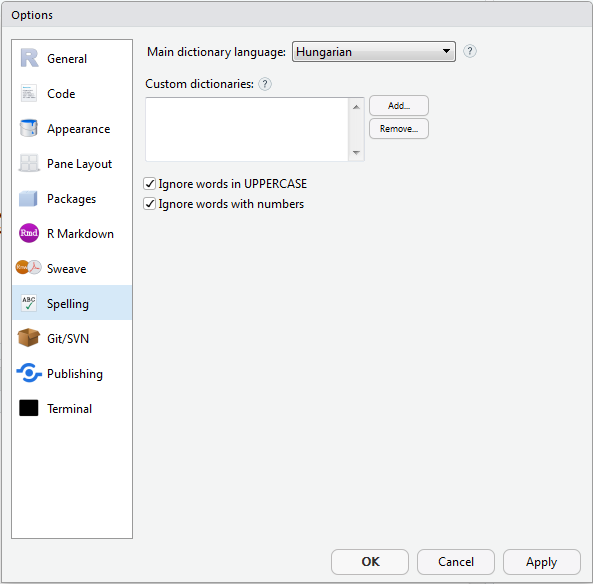

*Magyar helyesírási szótár kiválasztása*

## 4.5 Python code chunk

A .Rmd fájl nem korlátoz az R használatára, akár más programnyelvekből is beilleszthetünk kód részleteket, például Pythonból. A code chunk paraméterek az R kód részletekkel azonos módon működnek. Ahhoz, hogy a kód részlet működjön, telepítve kell, hogy legyen egy Python verzió, és a `reticulate` csomag, ami interface-t biztosít az R-nek a Pythonhoz. Ha nem szeretnénk telepíteni a csomagot, akkor választhatjuk a `python.reticulate = FALSE` beállítást. Ha a `knitr` nem találja a Python .exe fájlt, akkor azt az `engine.path` paraméterrel adhatjuk meg. Az én esetemben például `engine.path = 'C:/Users/Rendszergazda/AppData/Local/Programs/Python/Python36-32/python.exe'`. Az elérési útvonal megadásánál figyelni kell, hogy `\` helyett `/`-t használjunk. További olvasnivaló például [itt](http://rmarkdown.rstudio.com/authoring_knitr_engines.html) és [itt](https://github.com/rstudio/reticulate).

```python
import sys
print(sys.version)

x = 'hello, python world!'
print(x.split(' '))
```

```
## 3.6.4 (v3.6.4:d48eceb, Dec 19 2017, 06:04:45) [MSC v.1900 32 bit (Intel)]
## ['hello,', 'python', 'world!']
```

# Házi feladat

1. Készítsetek R Markdown dokumentumot a `gapminder` adatbázis alapján. A riport tartalmazzon egy összefoglaló táblázatot a kontinenseken mért (országos átlagokból számolt) átlagos várható élettartamról és egy főre jutó népességről 1952-ben és 2007-ben, és legalább egy plotot, ami segít érzékeltetni, hogy milyen változások történtek a kontinensek helyzetében a két idpont között. A táblázathoz és a plot(okhoz) írjatok magyarázó szöveget is.
2. A Gapminder adataihoz hasonlóan az ESS adatai is könnyen elérhetőek R csomagon keresztül. Ehhez az `ess` csomagot kell telepíteni, és regisztrálni az [ESS](http://www.europeansocialsurvey.org/user/new) oldalán, ha még nincs regisztrált email címetek. Töltsétek le egy tetszőleges kör adatait egy tetszőleges országra, és készítsetek egy legalább két plotot és magyarázatot tartalmazó elemzést egy titeket érdeklő kérdésről. Segítségképpen lent találtok egy kódot, amivel Dánia Round1 adatai kérhetőek le. A csomag [leírását](https://cran.r-project.org/web/packages/ess/ess.pdf) szintén érdemes megnézni.

```r
# Dánia 1. kör eredményei
# Az eredmény egy lista lesz
denmark_r1 <- ess_country("Denmark", 1, "email.címem@example.com")

# Ezt konvertálhatjuk data.frame-mé, tibble-é
denmark_r1_df <- as.tibble(as.data.frame(denmark_r1))

# Az első 10 változó
head(denmark_r1_df[,1:10])
```

# Hivatkozásjegyzék

Kabacoff, Robert. 2015. *R in Action: Data Analysis and Graphics with R*. 2 edition. Shelter Island: Manning Publications.